# Welcome to My Personal Programming Notebook!

snippets, links, cheat-sheets & boilerplate

[DevOps Roadmap](https://roadmap.sh/devops)

# JUPYTER NOTEBOOK (Conda)

/dunovank/jupyter-themes

[Jupyter notebook extensions](https://github.com/ipython-contrib/jupyter_contrib_nbextensions)

[Markdown Cheat Sheet](https://blogs.baruch.cuny.edu/cis3100/?p=52)

Embed Images

- ![<title>](attachment:<filepath>)

[Embed YouTubeVideo](https://stackoverflow.com/questions/22920355/how-to-change-embedded-video-size-and-alignment-on-ipython-notebook)

Convert Notebook (.ipynb) to HTML with TOC, or PDF

- jupyter nbconvert --to html_toc <notebook>.ipynb
- jupyter nbconvert --to pdf <notebook>.ipynb

Convert Notebook with HTML Embedded is found in File>Download as>HTML Embedded(.html)

## Anaconda

[Anaconda Virtual Environments](https://docs.conda.io/projects/conda/en/latest/user-guide/tasks/manage-environments.html)

# UBUNTU/LINUX

ctrl+a home

ctrl+e end

ctrl+u remove current line

tree -p similar to ls -l but with lines, -i without lines and permissions

Create all necessary folders in filepath

- mkdir -p

[What is /opt directory](https://askubuntu.com/questions/34880/use-of-opt-and-usr-local-directories-in-the-context-of-a-pc)

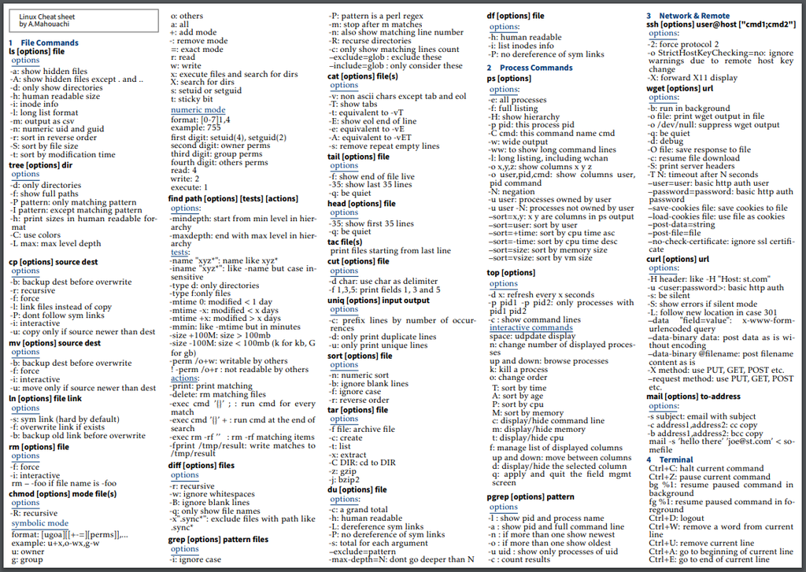

```python
from IPython.display import YouTubeVideo
YouTubeVideo('5iWhQWVXosU', width=800, height=300)
```

[video not shown]

Hiding Login/Password

- cd ~
- nano .bash_profile
- export USER="jdoe"
- export PASS="1234"
- ctrl-x, y
- source .bash_profile

[Backup/Copy Directory](https://askubuntu.com/questions/844876/how-do-you-copy-a-directory-and-its-contents-to-a-new-location-under-a-new-direc/844880)

[Copy SSH key to clipboard](https://www.digitalocean.com/community/questions/copy-ssh-key-to-clipboard)

CRONTAB

- Flags(-l:list, -r:remove, -e:edit)
- Use shell scripts(<scriptname.sh>
- Include "shebang" (#!bin/bash) as first line of shell script
- Export environment variables in shell script
- Use absolute path(/home/user/path/to/*)
- Use "." in place of "source" command for crontab
- Give file 744 permission(chmod 744 *.*)
- Use "MAILTO='foo@bar.net'" as first line in crontab to receive notification of every cronjob
- Cron logs to /var/log/syslog
- For cron specific logs(grep CRON /var/log/syslog)

[How to configure Postfix to use Gmail SMTP on Ubuntu 18.04 / 19.10](https://devanswers.co/configure-postfix-to-use-gmail-smtp-on-ubuntu-16-04-digitalocean-droplet/)

Remove all remnants of an install(sudo apt purge <app>)

# PYTHON

[Python Virtual Environment](https://linuxize.com/post/how-to-create-python-virtual-environments-on-ubuntu-18-04/)

- python3 -m venv <environment_name>
- source <environment_name>/bin/activate
- deactivate

[Sending Email With Python](https://realpython.com/python-send-email/)

PWD Server

- $ python -m SimpleHTTPServer 8080

# GIT

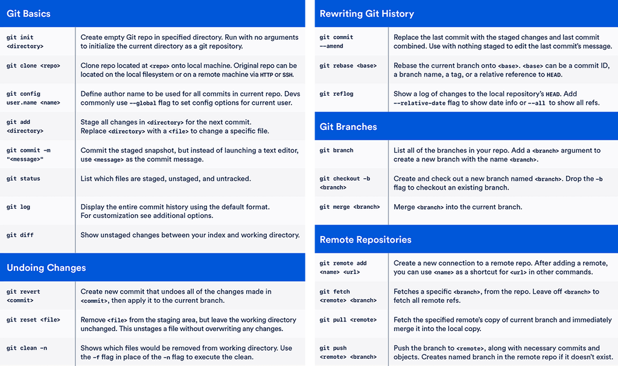

```python
from IPython.display import Image
Image(filename='gitcheat-1200x-top-c.png')
```

Git Cheat Sheet

```python
from IPython.display import YouTubeVideo
YouTubeVideo('HVsySz-h9r4', width=800, height=300)
```

[video not shown]

[git branching model](https://nvie.com/posts/a-successful-git-branching-model/)

[Atlassian git resources](https://www.atlassian.com/git/tutorials)

# DOCKER

Remember to add "." to the end of build commands to specify current directory

- sudo docker build -t <project> .

Play With Docker Tutorial

- sudo docker run -dp 80:80 docker/getting-started:pwd

[figure not shown]

```python
from IPython.display import Image
Image(filename='docker-cheat-sheet.png')
```

[UDBC Docker Lab](https://schoolofdevops.github.io/ultimate-devops-bootcamp/d02-docker-operations/)

Exec as root

- sudo docker exec -u 0 -it <mycontainer> <bash(ubuntu) or sh(alpine)>

sudo docker-compose up - starts all containers sudo docker-compose up -d - starts named container

Stop all running containers

- sudo docker stop $(sudo docker ps -a -q)
- sudo docker-compose down

Create a volume

- sudo docker volume create <name>

Named Volume

- sudo docker run -dp 3000:3000 -v todo-db:/etc/todos <tag>

Bind Mount

- sudo docker run -dp 3000:3000 \ -w /app -v $PWD:/app \ node:10-alpine \ sh -c "yarn install && yarn run dev"

Create Network

- sudo docker network create todo-app

Connecting to MySQL¶ Now that we know MySQL is up and running, let's use it! But, the question is... how? If we run another container on the same network, how do we find the container (remember each container has its own IP address)?

To figure it out, we're going to make use of the nicolaka/netshoot container, which ships with a lot of tools that are useful for troubleshooting or debugging networking issues.

Start a new container using the nicolaka/netshoot image. Make sure to connect it to the same network.

docker run -it --network todo-app nicolaka/netshoot Inside the container, we're going to use the dig command, which is a useful DNS tool. We're going to look up the IP address for the hostname mysql.

dig mysql And you'll get an output like this...

;; QUESTION SECTION: ;mysql. IN A

;; ANSWER SECTION: mysql. 600 IN A 172.23.0.2

What this means is... our app only simply needs to connect to a host named mysql and it'll talk to the database! It doesn't get much simpler than that!

Connecting to MYSQL

- sudo docker run -dp 3000:3000 \ -w /app -v $PWD:/app \ --network todo-app \ -e MYSQL_HOST=mysql \ -e MYSQL_USER=root \ -e MYSQL_PASSWORD=secret \ -e MYSQL_DB=todos \ node:10-alpine \ sh -c "yarn install && yarn run dev"

Enter MYSQL

- sudo docker exec -ti mysql -p todos

# JENKINS

[Getting Started with Jenkins](https://jenkins.io/doc/pipeline/tour/getting-started/)

[SchoolofDevops-learn-jenkins](https://github.com/schoolofdevops/learn-jenkins)

Run Jenkins (Directory must contain jenkins.war file)

- java -jar jenkins.war --httpPort=8080

Trigger Remote Build

- http://<username>:<api-token>@localhost:8080/job/<job-name>/build?token=<authentication-token>

Create Jenkins Pipeline With Jenkinsfile

- install pipeline plugin
- fork and clone source code
- cd to directory
- [create Jenkinsfile](https://jenkins.io/doc/book/pipeline/jenkinsfile/) with $ nano Jenkinsfile
- git add Jenkinsfile, commit and push origin master
- create new item as pipeline, include repo link

# ANSIBLE

```python
from IPython.display import YouTubeVideo
YouTubeVideo('MfoAb50Br94', width=800, height=300)
```

[video not shown]

# KIVY

[Kivy Tutorial - @techwithtim](https://techwithtim.net/tutorials/kivy-tutorial/setup/)

[Build a Mobile App- @realpython](https://realpython.com/mobile-app-kivy-python/)

[Kivy Tutorials- @likegeeks](https://likegeeks.com/kivy-tutorial/)

```python
from IPython.display import YouTubeVideo
YouTubeVideo('nI9mjajX4TI', width=800, height=300)
```

[video not shown]

# BUILDOZER

[Build a Mobile App- @realpython](https://realpython.com/mobile-app-kivy-python/)

[Buildozer Dependencies](https://buildozer.readthedocs.io/en/latest/installation.html#targeting-android)

Setup

- pip3 install buildozer
- Then, create a new folder and navigate to it in your terminal. Once you’re there, you’ll need to run the following command:
- buildozer init
- This will create a buildozer.spec file that you’ll use to configure your build. For this example, you can edit the first few lines of the spec file as follows: [app]
- (str) Title of your application title = KvCalc
- (str) Package name package.name = kvcalc
- (str) Package domain (needed for android/ios packaging) package.domain = org.kvcalc
- At this point, you’re almost ready to build your application, but first, you’ll want to install the dependencies for buildozer. Once those are installed, copy your calculator application into your new folder and rename it to main.py. This is required by buildozer. If you don’t have the file named correctly, then the build will fail.
- buildozer -v android debug

# ADB

[Logcat Command Line Tool](https://developer.android.com/studio/command-line/logcat?hl=zh-cn#Syntax)

# FLASK

Basic Setup

- Create python virtual environment (python3 -m venv <env_name>)
- Activate virtual environment (source <env_name>/bin/activate)
- Create a basic python script without html

```
from flask import Flask
app = Flask(__name__)
@app.route('/')
def hello():
    return "Hello World!"
if __name__ == '__main__':
    app.run()
```

- Create a templates folder for .html files (mkdir templates)
- Create a basic python script with html

```
from flask import Flask, render_template
app = Flask(__name__)
@app.route('/')
def home():
    return render_template('<name\>.html')
if __name__ == '__main__':
    app.run()
```

Debug Mode

```
if __name__ == '__main__':
app.run(debug=True)
```

Basic UnitTest

```
import <project>
import unittest


class MyTestCase(unittest.TestCase):

def setUp(self):
    <project>.app.testing = True
    self.app = <project>.app.test_client()

def test_home(self):
    response = self.app.get('/')
    # Make your assertions
    self.assertEqual(response.status_code, 200)

if __name__ == "__main__":
    unittest.main()
```

# DEPLOYING FLASK APP TO LINUX SERVER

Setup ssh in Remote Server

- # ssh root@<ip_address>
- # apt update && apt upgrade
- # hostnamectl set-hostname <name>
- # nano /etc/hosts (add ip and hostname)

/etc/hosts

```
127.0.0.1       localhost
<ip_address\>  <hostname\>
 The following lines are desirable for IPv6 capable hosts
::1     localhost ip6-localhost ip6-loopback
ff02::1 ip6-allnodes
ff02::2 ip6-allrouters
```

- # adduser <username>
- # adduser <username> sudo
- # ssh <username>@
- \$ mkdir ~/.ssh

Local Machine

- \$ ssh-keygen -b 4096
- \$ scp ~/.ssh/id_rsa.pub <username>@<ip_address>:~/.ssh/authorized_keys

Remote Server

- \$ sudo chmod 700 ~/.ssh/
- \$ sudo chmod 600 ~/.ssh/*

Disable Root on Remote Server

- \$ sudo nano /etc/ssh/sshd_config (PasswordAuthentication=no, PermitRootLogin=no)
- \$ sudo systemctl restart sshd

Firewall for Remote Server

- \$ sudo apt install ufw
- \$ sudo ufw default allow outgoing
- \$ sudo ufw default deny incoming
- \$ sudo ufw allow ssh
- \$ sudo ufw allow 5000
- \$ sudo ufw enable
- \$ sudo ufw status

*After Installing Nginx*

- \$ sudo ufw allow http/tcp
- \$ sudo ufw delete allow 5000

Create requirements.txt on Local Machine

- \$ pip3 freeze > requirements.txt
- \$ scp -r ~/<project_folder> <username>@<ip_address>:~/

Configure App on Remote Server

- \$ sudo apt install python3-pip
- \$ sudo apt install python3-venv
- \$ python3 -m venv <<project_folder>/<environment_name>>
- \$ cd <project_folder>
- \$ source <environment_name>/bin/activate
- \$ pip install -r requirements.txt

*Optional*

To create a json file for environment variables

- \$ sudo touch /etc/confg.json
- \$ sudo nano config.py *Update to access environment variables from config.json with .get() method*

Run Flask with Default server

- \$ export FLASK_APP=<project_name>.py
- \$ flask run --host=0.0.0.0

Install Nginx and Gunicorn on Remote Server

- \$ sudo apt install nginx
- \$ pip install gunicorn
- \$ sudo rm /etc/nginx/sites-enabled/default
- \$ sudo nano /etc/nginx/sites-enabled/<project_name>

Nginx configuration <project_name>

```
server {
    listen 80;
    server_name <ip_address>;
    location /static {
         alias /home/<username>/<project_folder>/static;
    }
    location / {
        proxy_pass http://localhost:8000;
        include /etc/nginx/proxy_params;
        proxy_redirect off;
    }
```

*Update Firewall*

- \$ sudo ufw allow http/tcp
- \$ sudo ufw delete allow 5000

*Restart Nginx*

- \$ sudo systemctl restart nginx

*Install Supervisor*

- \$ sudo apt install supervisor
- \$ sudo nano /etc/supervisor/conf.d/<project_name>.conf

<project_name>.conf

```
[program:jupyter_page]
directory=/home/jmrobinson/jupyterpage
command=/home/jmrobinson/jupyterpage/jupyter_env/bin/gunicorn -w 3 jupyter_page>
user=jmrobinson
autostart=true
autorestart=true
stopasgroup=true
killasgroup=true
stderr_logfile=/var/log/jupyterpage/jupyterpage.err.log
stdout_logfile=/var/log/jupyterpage/jupyterpage.out.log
```

*Create Log Files*

- \$ sudo touch /var/log/<project_name>/<project_name>.err.log
- \$ sudo touch /var/log/<project_name>/<project_name>.out.log
- \$ sudo supervisorctl reload

Encrypt with LetsEncrypt/Certbot

- \$ sudo apt update
- \$ sudo apt install software-properties-common
- \$ sudo add-apt-repository universe
- \$ sudo add-apt-repository ppa:certbot/certbot
- \$ sudo apt update
- \$ sudo apt install python-certbot-nginx *The nginx config file may be updated to show domain instead of ip*
- \$ sudo certbot --nginx

*Allow Https Traffic Through Firewall*

- \$ sudo ufw allow https

# SQLALCHEMY

Basic Template

```
from sqlalchemy import create_engine, Column, String
from sqlalchemy.ext.declarative import declarative_base
from sqlalchemy.orm import sessionmaker, relationship

Base = declarative_base()
class Posts(Base):

    __tablename__ = "base"

    timing = Column(String(120), unique=False, nullable=False,   primary_key=True)
    title_text = Column(String(120), unique=False, nullable=False)
    price = Column(String(120), unique=False, nullable=False)
    link = Column(String(120), unique=False, nullable=False)

engine = create_engine('sqlite:///search_results.db')  #echo=True for output to console
                             # ^^^ or ////home/user/path/to/folder
Base.metadata.create_all(bind=engine)
Session = sessionmaker(bind=engine)
session = Session()

session.add(post)
session.commit()
session.close()
```

Catch IntegrityError

```
   from sqlalchemy import exc

   try:
       pass
   except exc.IntegrityError as e:
       session.rollback()
```